# Affine Transforms

```python
import numpy as np
# set the print opts sensibly to keep things tidy
np.set_printoptions(linewidth=500, precision=2)

from menpo.transform import Rotation, Scale, Translation
```

```python
rotation_m = np.array([[ 0.36,  0.48, -0.80],
                       [-0.80,  0.60,  0.00],
                       [ 0.48,  0.64,  0.60]])
scale = np.array([7,3, 15])
translation = np.array([-1,20])
```

```python
r = Rotation(rotation_m)
nus = Scale([7,3, 15])   # NonUniformScale (Affine)
us = Scale(2, n_dims=3)  # UniformScale (Similarity)
t = Translation([-1,20])
```

All affine transforms are printable. You will see the usual homogeneous matrix, and an English decription of what the affine transform does

```python
print(r)
```

```
CCW Rotation of -73.7 degrees about [-0.33  0.67  0.67]
[[ 0.36  0.48 -0.8   0.  ]
 [-0.8   0.6   0.    0.  ]
 [ 0.48  0.64  0.6   0.  ]
 [ 0.    0.    0.    1.  ]]
```

```python
print(nus)
```

```
NonUniformScale by [  7.   3.  15.]
[[  7.   0.   0.   0.]
 [  0.   3.   0.   0.]
 [  0.   0.  15.   0.]
 [  0.   0.   0.   1.]]
```

```python
print(t)
```

```
Translation by [ -1.  20.]
[[  1.   0.  -1.]
 [  0.   1.  20.]
 [  0.   0.   1.]]
```

All these are instances of `DiscreteAffine`. That means we can ask any of these to invert themselves

```python
print(us)
print(us.pseudoinverse)
```

```
UniformScale by 2.0
[[ 2.  0.  0.  0.]
 [ 0.  2.  0.  0.]
 [ 0.  0.  2.  0.]
 [ 0.  0.  0.  1.]]
UniformScale by 0.5
[[ 0.5  0.   0.   0. ]
 [ 0.   0.5  0.   0. ]
 [ 0.   0.   0.5  0. ]
 [ 0.   0.   0.   1. ]]
```

```python
rotation_followed_by_scale = r.compose_before(nus)
print(rotation_followed_by_scale)
```

```
Affine decomposing into:
  CCW Rotation of 120.0 degrees about [ 0.12 -0.81  0.58]
  NonUniformScale by [ 15.   7.   3.]
  CCW Rotation of -120.0 degrees about [-0.58 -0.58  0.58]
  Translation by [ 0.  0.  0.]
[[ 2.52  3.36 -5.6   0.  ]
 [-2.4   1.8   0.    0.  ]
 [ 7.2   9.6   9.    0.  ]
 [ 0.    0.    0.    1.  ]]
```

We can request this sequence directly by using the `decompose()` method  
*notice how all affine transforms support eqality checking*

```python
decomposed = rotation_followed_by_scale.decompose()
result_of_chain = reduce(lambda x, y: x.compose_before(y), decomposed)
print(result_of_chain)
print('Does chaining the decomposition do '
      'the same as the original? {}'.format(result_of_chain == rotation_followed_by_scale))
```

```
Affine decomposing into:
  CCW Rotation of 120.0 degrees about [ 0.12 -0.81  0.58]
  NonUniformScale by [ 15.   7.   3.]
  CCW Rotation of -120.0 degrees about [-0.58 -0.58  0.58]
  Translation by [ 0.  0.  0.]
[[  2.52e+00   3.36e+00  -5.60e+00   0.00e+00]
 [ -2.40e+00   1.80e+00   1.26e-15   0.00e+00]
 [  7.20e+00   9.60e+00   9.00e+00   0.00e+00]
 [  0.00e+00   0.00e+00   0.00e+00   1.00e+00]]
Does chaining the decomposition do the same as the original? True
```

Note that chaining `Similarity` objects together yields a `Similarity` instead.

```python
print(r.compose_before(us))
```

```
Similarity decomposing into:
  CCW Rotation of -102.9 degrees about [ 0.43 -0.43  0.8 ]
  UniformScale by 2.0
  CCW Rotation of 113.5 degrees about [ 0.01 -0.93  0.38]
  Translation by [ 0.  0.  0.]
[[ 0.72  0.96 -1.6   0.  ]
 [-1.6   1.2   0.    0.  ]
 [ 0.96  1.28  1.2   0.  ]
 [ 0.    0.    0.    1.  ]]
```

Finally, note that all instances of `Transform` are guaranteed to have an `.apply()` method. Novel points can be passed in here, which will then be transformed (the result is returned, and the points left as they are). However, objects passed into `apply()` can define a `._transform()` method, signifing that this object knows how to handle it's own transformation. In this case, the trasformation is applied in place. `PointCloud` is one such class that defines this method.

```
PointCloud: n_points: 4, n_dims: 2
[[ 0.  0.]
 [ 1.  0.]
 [ 1.  1.]
 [ 0.  1.]]
```

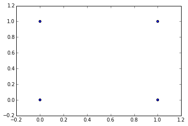

```python
%matplotlib inline
from menpo.shape import PointCloud
points = np.array([[0.0, 0.0],
                   [1.0, 0.0],
                   [1.0, 1.0],
                   [0.0, 1.0]])
pc = PointCloud(points)
print(pc)
print(pc.points)
pc.view();
```

A transform can `.apply()` to some raw points to yield new ones...

```
[[ -1.  20.]
 [  0.  20.]
 [  0.  21.]
 [ -1.  21.]]
```

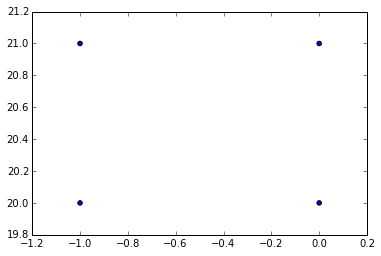

```python
import matplotlib.pyplot as plt
new_points = t.apply(points)
print(new_points)
plt.scatter(new_points[:, 0], new_points[:, 1]);
```

..or can apply directly to `Transformable` objects.

```
[[ -1.  20.]
 [  0.  20.]
 [  0.  21.]
 [ -1.  21.]]
```

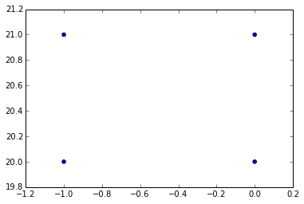

```python
pc3 = t.apply(pc)
print(pc3.points)
pc3.view();
```